# Project Title: Fraud Detection in Credit Card Transactions

## Introduction

Welcome to my project on fraud detection in credit card transactions! In this project, I aim to develop machine learning models to detect fraudulent transactions in credit card data.

## Project Information

### Developer:

- Name: Anuj Rastogi

### Date of Completion:

- 09-01-2024

### Data Source:

The dataset used in this project is obtained from Kaggle. It contains credit card transactions made by European cardholders in September 2013, where we aim to identify fraudulent transactions.

You can find the dataset here: [Credit Card Fraud Detection - Kaggle](https://www.kaggle.com/mlg-ulb/creditcardfraud)

## About the Dataset

The dataset contains transactions made by credit cards in September 2013 by European cardholders. It includes a total of 284,807 transactions, of which 492 are fraudulent. The features in the dataset are anonymized due to privacy concerns.

### Features:

- Time: Time elapsed between each transaction and the first transaction in seconds.
- V1-V28: Anonymized features resulting from PCA transformation for confidentiality.
- Amount: Transaction amount.
- Class: Indicates whether the transaction is fraudulent (1) or not (0).

## Methodology

1. Data Preprocessing: Cleaning the data, handling missing values, and scaling features.
2. Exploratory Data Analysis: Understanding the distribution of features and identifying patterns.
3. Model Development: Training machine learning models for fraud detection.
4. Model Evaluation: Assessing model performance using metrics such as accuracy, precision, recall, and F1-score.
5. Conclusion: Summarizing findings and discussing potential areas for improvement.

Let's dive into the project and start exploring the data!

### Context

It is important that credit card companies are able to recognize fraudulent credit card transactions so that customers are not charged for items that they did not purchase.

### Content

The datasets contains transactions made by credit cards in September 2013 by european cardholders. This dataset presents transactions that occurred in two days, where we have 492 frauds out of 284,807 transactions. The dataset is highly unbalanced, the positive class (frauds) account for 0.172% of all transactions.

It contains only numerical input variables which are the result of a PCA transformation. Unfortunately, due to confidentiality issues, we cannot provide the original features and more background information about the data. Features V1, V2, ... V28 are the principal components obtained with PCA, the only features which have not been transformed with PCA are 'Time' and 'Amount'. Feature 'Time' contains the seconds elapsed between each transaction and the first transaction in the dataset. The feature 'Amount' is the transaction Amount, this feature can be used for example-dependant cost-senstive learning. Feature 'Class' is the response variable and it takes value 1 in case of fraud and 0 otherwise.

### Inspiration

Identify fraudulent credit card transactions.

Given the class imbalance ratio, we recommend measuring the accuracy using the Area Under the Precision-Recall Curve (AUPRC). Confusion matrix accuracy is not meaningful for unbalanced classification.

### Acknowledgements

The dataset has been collected and analysed during a research collaboration of Worldline and the Machine Learning Group (http://mlg.ulb.ac.be) of ULB (Université Libre de Bruxelles) on big data mining and fraud detection. More details on current and past projects on related topics are available on https://www.researchgate.net/project/Fraud-detection-5 and the page of the DefeatFraud project

```python
import numpy as np  # Numerical operations and array handling
import pandas as pd  # Data manipulation and analysis
import sklearn  # Machine learning algorithms and utilities
import scipy  # Scientific computing and mathematical functions
import matplotlib.pyplot as plt  # Plotting and visualization
import seaborn as sns  # Enhanced plotting library for visualizations
from sklearn.metrics import classification_report, accuracy_score  # Evaluation metrics for models
from sklearn.ensemble import IsolationForest  # Anomaly detection algorithm: Isolation Forest
from sklearn.neighbors import LocalOutlierFactor  # Anomaly detection algorithm: Local Outlier Factor
from sklearn.svm import OneClassSVM  # Anomaly detection algorithm: One-Class SVM
from pylab import rcParams  # Customizing plot sizes and styles
rcParams['figure.figsize'] = 14, 8  # Setting default plot size
RANDOM_SEED = 42  # Seed value for reproducibility
LABELS = ["Normal", "Fraud"]  # Labels for classification
```

```python
data = pd.read_csv('creditcard.csv',sep=',')
data.head()
```

|  | Time | V1 | V2 | V3 | V4 | V5 | V6 | V7 | V8 | V9 | ... | V21 | V22 | V23 | V24 | V25 | V26 | V27 | V28 | Amount | Class |
| --- | --- | --- | --- | --- | --- | --- | --- | --- | --- | --- | --- | --- | --- | --- | --- | --- | --- | --- | --- | --- | --- |
| 0 | 0.0 | -1.359807 | -0.072781 | 2.536347 | 1.378155 | -0.338321 | 0.462388 | 0.239599 | 0.098698 | 0.363787 | ... | -0.018307 | 0.277838 | -0.110474 | 0.066928 | 0.128539 | -0.189115 | 0.133558 | -0.021053 | 149.62 | 0 |
| 1 | 0.0 | 1.191857 | 0.266151 | 0.166480 | 0.448154 | 0.060018 | -0.082361 | -0.078803 | 0.085102 | -0.255425 | ... | -0.225775 | -0.638672 | 0.101288 | -0.339846 | 0.167170 | 0.125895 | -0.008983 | 0.014724 | 2.69 | 0 |
| 2 | 1.0 | -1.358354 | -1.340163 | 1.773209 | 0.379780 | -0.503198 | 1.800499 | 0.791461 | 0.247676 | -1.514654 | ... | 0.247998 | 0.771679 | 0.909412 | -0.689281 | -0.327642 | -0.139097 | -0.055353 | -0.059752 | 378.66 | 0 |
| 3 | 1.0 | -0.966272 | -0.185226 | 1.792993 | -0.863291 | -0.010309 | 1.247203 | 0.237609 | 0.377436 | -1.387024 | ... | -0.108300 | 0.005274 | -0.190321 | -1.175575 | 0.647376 | -0.221929 | 0.062723 | 0.061458 | 123.50 | 0 |
| 4 | 2.0 | -1.158233 | 0.877737 | 1.548718 | 0.403034 | -0.407193 | 0.095921 | 0.592941 | -0.270533 | 0.817739 | ... | -0.009431 | 0.798278 | -0.137458 | 0.141267 | -0.206010 | 0.502292 | 0.219422 | 0.215153 | 69.99 | 0 |

5 rows × 31 columns

```python
data.info()
```

```
<class 'pandas.core.frame.DataFrame'>
RangeIndex: 284807 entries, 0 to 284806
Data columns (total 31 columns):
 #   Column  Non-Null Count   Dtype
---  ------  --------------   -----
 0   Time    284807 non-null  float64
 1   V1      284807 non-null  float64
 2   V2      284807 non-null  float64
 3   V3      284807 non-null  float64
 4   V4      284807 non-null  float64
 5   V5      284807 non-null  float64
 6   V6      284807 non-null  float64
 7   V7      284807 non-null  float64
 8   V8      284807 non-null  float64
 9   V9      284807 non-null  float64
```

[output cut: 23 more lines]

## Exploratory Data Analysis

```python
data.isnull().values.any()
```

```
False
```

```python
# Understanding my target variable distribution
data.Class.value_counts(normalize=True)
```

```
Class
0    0.998273
1    0.001727
Name: proportion, dtype: float64
```

```python
# Get the Fraud dataset by filtering the 'data' DataFrame where the 'Class' column equals 1 (indicating fraud)
fraud = data[data['Class']==1]

# Get the Normal dataset by filtering the 'data' DataFrame where the 'Class' column equals 0 (indicating normal transactions)
normal = data[data['Class']==0]
```

#### We can conclude that our data is highly imbalance as the count of fraud transactions is significantly low compared to normal transactions

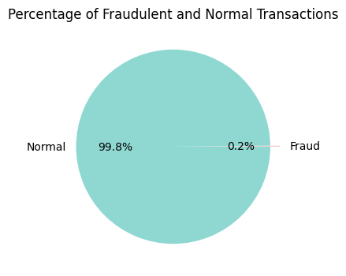

```python
import matplotlib.pyplot as plt  # Importing matplotlib for plotting

# Create a new figure with a specific size
plt.figure(figsize=(4, 4))

# Plot a pie chart showing the percentage of fraudulent and normal transactions
# 'autopct' specifies the format of the percentage display on each slice
# 'colors' sets the colors for the slices
# 'explode' specifies the fraction of the radius with which to offset each wedge
plt.pie([len(fraud), len(normal)], labels=['Fraud', 'Normal'], autopct='%1.1f%%', colors=['#f7cac9', '#8fd8d2'], explode=(0.1, 0))

# Set the title of the plot
plt.title('Percentage of Fraudulent and Normal Transactions')

# Display the plot
plt.show()
```

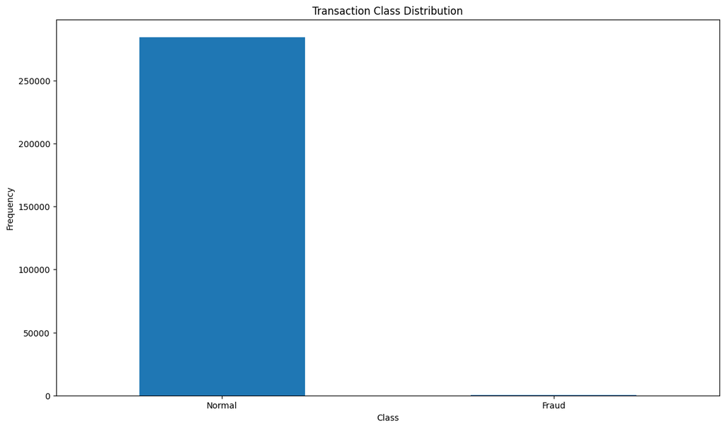

```python
# Count the number of occurrences of each class in the 'Class' column of the DataFrame 'data'
count_classes = pd.value_counts(data['Class'], sort=True)

# Plot the distribution of transaction classes as a bar plot
# 'kind' parameter specifies the type of plot, 'rot=0' ensures the x-axis labels are not rotated
count_classes.plot(kind='bar', rot=0)

# Set the title of the plot
plt.title("Transaction Class Distribution")

# Set the x-axis labels to 'LABELS', which is a list containing the class labels "Normal" and "Fraud"
plt.xticks(range(2), LABELS)

# Set the label for the x-axis
plt.xlabel("Class")

# Set the label for the y-axis
plt.ylabel("Frequency")
```

```python
print(fraud.shape,normal.shape)
```

```
(492, 31) (284315, 31)
```

```python
## We need to analyze more amount of information from the transaction data
#How different are the amount of money used in different transaction classes?
fraud.Amount.describe()
```

```
count     492.000000
mean      122.211321
std       256.683288
min         0.000000
25%         1.000000
50%         9.250000
75%       105.890000
max      2125.870000
Name: Amount, dtype: float64
```

```python
normal.Amount.describe()
```

```
count    284315.000000
mean         88.291022
std         250.105092
min           0.000000
25%           5.650000
50%          22.000000
75%          77.050000
max       25691.160000
Name: Amount, dtype: float64
```

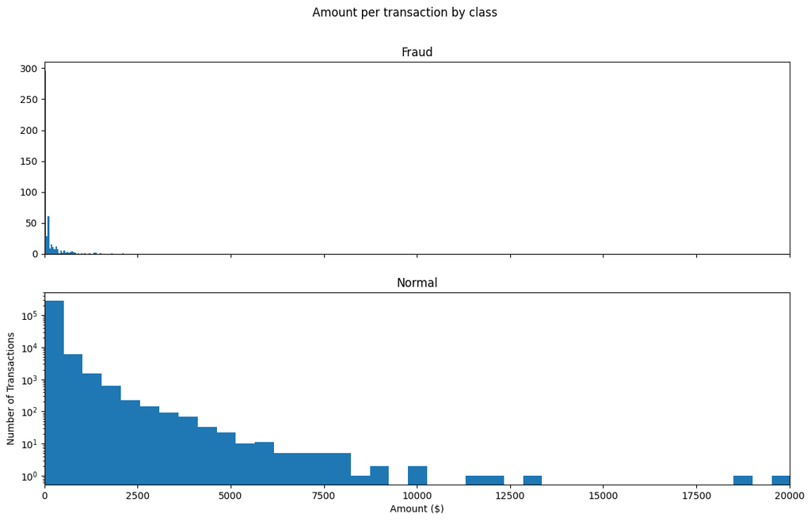

```python
# Create a figure with two subplots arranged vertically and sharing the x-axis
f, (ax1, ax2) = plt.subplots(2, 1, sharex=True)

# Set the title for the entire figure
f.suptitle('Amount per transaction by class')

# Define the number of bins for the histograms
bins = 50

# Plot the histogram of amounts for fraudulent transactions on the first subplot
ax1.hist(fraud['Amount'], bins=bins)
ax1.set_title('Fraud')  # Set the title for the first subplot

# Plot the histogram of amounts for normal transactions on the second subplot
ax2.hist(normal['Amount'], bins=bins)
ax2.set_title('Normal')  # Set the title for the second subplot

# Set the label for the x-axis
plt.xlabel('Amount ($)')

# Set the label for the y-axis
plt.ylabel('Number of Transactions')

# Set the limit for the x-axis to show only amounts up to $20,000
plt.xlim((0, 20000))

# Set the scale of the y-axis to logarithmic for better visualization of distribution
plt.yscale('log')

# Display the plot
plt.show()
```

```python
# Printing fraud dataset
fraud
```

|  | Time | V1 | V2 | V3 | V4 | V5 | V6 | V7 | V8 | V9 | ... | V21 | V22 | V23 | V24 | V25 | V26 | V27 | V28 | Amount | Class |
| --- | --- | --- | --- | --- | --- | --- | --- | --- | --- | --- | --- | --- | --- | --- | --- | --- | --- | --- | --- | --- | --- |
| 541 | 406.0 | -2.312227 | 1.951992 | -1.609851 | 3.997906 | -0.522188 | -1.426545 | -2.537387 | 1.391657 | -2.770089 | ... | 0.517232 | -0.035049 | -0.465211 | 0.320198 | 0.044519 | 0.177840 | 0.261145 | -0.143276 | 0.00 | 1 |
| 623 | 472.0 | -3.043541 | -3.157307 | 1.088463 | 2.288644 | 1.359805 | -1.064823 | 0.325574 | -0.067794 | -0.270953 | ... | 0.661696 | 0.435477 | 1.375966 | -0.293803 | 0.279798 | -0.145362 | -0.252773 | 0.035764 | 529.00 | 1 |
| 4920 | 4462.0 | -2.303350 | 1.759247 | -0.359745 | 2.330243 | -0.821628 | -0.075788 | 0.562320 | -0.399147 | -0.238253 | ... | -0.294166 | -0.932391 | 0.172726 | -0.087330 | -0.156114 | -0.542628 | 0.039566 | -0.153029 | 239.93 | 1 |
| 6108 | 6986.0 | -4.397974 | 1.358367 | -2.592844 | 2.679787 | -1.128131 | -1.706536 | -3.496197 | -0.248778 | -0.247768 | ... | 0.573574 | 0.176968 | -0.436207 | -0.053502 | 0.252405 | -0.657488 | -0.827136 | 0.849573 | 59.00 | 1 |
| 6329 | 7519.0 | 1.234235 | 3.019740 | -4.304597 | 4.732795 | 3.624201 | -1.357746 | 1.713445 | -0.496358 | -1.282858 | ... | -0.379068 | -0.704181 | -0.656805 | -1.632653 | 1.488901 | 0.566797 | -0.010016 | 0.146793 | 1.00 | 1 |
| ... | ... | ... | ... | ... | ... | ... | ... | ... | ... | ... | ... | ... | ... | ... | ... | ... | ... | ... | ... | ... | ... |
| 279863 | 169142.0 | -1.927883 | 1.125653 | -4.518331 | 1.749293 | -1.566487 | -2.010494 | -0.882850 | 0.697211 | -2.064945 | ... | 0.778584 | -0.319189 | 0.639419 | -0.294885 | 0.537503 | 0.788395 | 0.292680 | 0.147968 | 390.00 | 1 |
| 280143 | 169347.0 | 1.378559 | 1.289381 | -5.004247 | 1.411850 | 0.442581 | -1.326536 | -1.413170 | 0.248525 | -1.127396 | ... | 0.370612 | 0.028234 | -0.145640 | -0.081049 | 0.521875 | 0.739467 | 0.389152 | 0.186637 | 0.76 | 1 |
| 280149 | 169351.0 | -0.676143 | 1.126366 | -2.213700 | 0.468308 | -1.120541 | -0.003346 | -2.234739 | 1.210158 | -0.652250 | ... | 0.751826 | 0.834108 | 0.190944 | 0.032070 | -0.739695 | 0.471111 | 0.385107 | 0.194361 | 77.89 | 1 |
| 281144 | 169966.0 | -3.113832 | 0.585864 | -5.399730 | 1.817092 | -0.840618 | -2.943548 | -2.208002 | 1.058733 | -1.632333 | ... | 0.583276 | -0.269209 | -0.456108 | -0.183659 | -0.328168 | 0.606116 | 0.884876 | -0.253700 | 245.00 | 1 |
| 281674 | 170348.0 | 1.991976 | 0.158476 | -2.583441 | 0.408670 | 1.151147 | -0.096695 | 0.223050 | -0.068384 | 0.577829 | ... | -0.164350 | -0.295135 | -0.072173 | -0.450261 | 0.313267 | -0.289617 | 0.002988 | -0.015309 | 42.53 | 1 |

492 rows × 31 columns

```python
# printing normal dataset
normal
```

|  | Time | V1 | V2 | V3 | V4 | V5 | V6 | V7 | V8 | V9 | ... | V21 | V22 | V23 | V24 | V25 | V26 | V27 | V28 | Amount | Class |
| --- | --- | --- | --- | --- | --- | --- | --- | --- | --- | --- | --- | --- | --- | --- | --- | --- | --- | --- | --- | --- | --- |
| 0 | 0.0 | -1.359807 | -0.072781 | 2.536347 | 1.378155 | -0.338321 | 0.462388 | 0.239599 | 0.098698 | 0.363787 | ... | -0.018307 | 0.277838 | -0.110474 | 0.066928 | 0.128539 | -0.189115 | 0.133558 | -0.021053 | 149.62 | 0 |
| 1 | 0.0 | 1.191857 | 0.266151 | 0.166480 | 0.448154 | 0.060018 | -0.082361 | -0.078803 | 0.085102 | -0.255425 | ... | -0.225775 | -0.638672 | 0.101288 | -0.339846 | 0.167170 | 0.125895 | -0.008983 | 0.014724 | 2.69 | 0 |
| 2 | 1.0 | -1.358354 | -1.340163 | 1.773209 | 0.379780 | -0.503198 | 1.800499 | 0.791461 | 0.247676 | -1.514654 | ... | 0.247998 | 0.771679 | 0.909412 | -0.689281 | -0.327642 | -0.139097 | -0.055353 | -0.059752 | 378.66 | 0 |
| 3 | 1.0 | -0.966272 | -0.185226 | 1.792993 | -0.863291 | -0.010309 | 1.247203 | 0.237609 | 0.377436 | -1.387024 | ... | -0.108300 | 0.005274 | -0.190321 | -1.175575 | 0.647376 | -0.221929 | 0.062723 | 0.061458 | 123.50 | 0 |
| 4 | 2.0 | -1.158233 | 0.877737 | 1.548718 | 0.403034 | -0.407193 | 0.095921 | 0.592941 | -0.270533 | 0.817739 | ... | -0.009431 | 0.798278 | -0.137458 | 0.141267 | -0.206010 | 0.502292 | 0.219422 | 0.215153 | 69.99 | 0 |
| ... | ... | ... | ... | ... | ... | ... | ... | ... | ... | ... | ... | ... | ... | ... | ... | ... | ... | ... | ... | ... | ... |
| 284802 | 172786.0 | -11.881118 | 10.071785 | -9.834783 | -2.066656 | -5.364473 | -2.606837 | -4.918215 | 7.305334 | 1.914428 | ... | 0.213454 | 0.111864 | 1.014480 | -0.509348 | 1.436807 | 0.250034 | 0.943651 | 0.823731 | 0.77 | 0 |
| 284803 | 172787.0 | -0.732789 | -0.055080 | 2.035030 | -0.738589 | 0.868229 | 1.058415 | 0.024330 | 0.294869 | 0.584800 | ... | 0.214205 | 0.924384 | 0.012463 | -1.016226 | -0.606624 | -0.395255 | 0.068472 | -0.053527 | 24.79 | 0 |
| 284804 | 172788.0 | 1.919565 | -0.301254 | -3.249640 | -0.557828 | 2.630515 | 3.031260 | -0.296827 | 0.708417 | 0.432454 | ... | 0.232045 | 0.578229 | -0.037501 | 0.640134 | 0.265745 | -0.087371 | 0.004455 | -0.026561 | 67.88 | 0 |
| 284805 | 172788.0 | -0.240440 | 0.530483 | 0.702510 | 0.689799 | -0.377961 | 0.623708 | -0.686180 | 0.679145 | 0.392087 | ... | 0.265245 | 0.800049 | -0.163298 | 0.123205 | -0.569159 | 0.546668 | 0.108821 | 0.104533 | 10.00 | 0 |
| 284806 | 172792.0 | -0.533413 | -0.189733 | 0.703337 | -0.506271 | -0.012546 | -0.649617 | 1.577006 | -0.414650 | 0.486180 | ... | 0.261057 | 0.643078 | 0.376777 | 0.008797 | -0.473649 | -0.818267 | -0.002415 | 0.013649 | 217.00 | 0 |

284315 rows × 31 columns

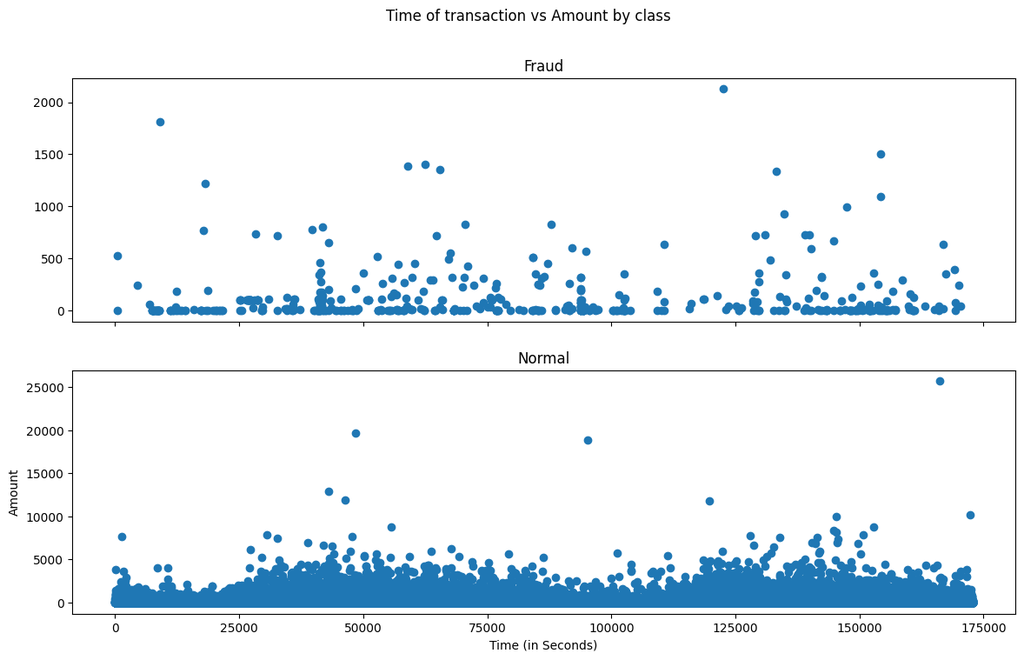

```python
# We Will check Do fraudulent transactions occur more often during certain time frame ? Let us find out with a visual representation.

f, (ax1, ax2) = plt.subplots(2, 1, sharex=True)
f.suptitle('Time of transaction vs Amount by class')
ax1.scatter(fraud['Time'], fraud['Amount'])
ax1.set_title('Fraud')
ax2.scatter(normal['Time'], normal['Amount'])
ax2.set_title('Normal')
plt.xlabel('Time (in Seconds)')
plt.ylabel('Amount')
plt.show()
```

```python
# Take a random sample of 10% of the original data with a specified random state for reproducibility
data1 = data.sample(frac=0.1, random_state=1)

# Display the shape of the sampled data
# This helps to verify the size of the sampled data
data1.shape

# This sampling process is performed to reduce the time taken for pre-processing since the original dataset is large
```

```
(28481, 31)
```

```python
data.shape
```

```
(284807, 31)
```

```python
# Determine the number of fraudulent transactions by filtering the sampled data where the 'Class' column equals 1
Fraud = data1[data1['Class']==1]

# Determine the number of valid (non-fraudulent) transactions by filtering the sampled data where the 'Class' column equals 0
Valid = data1[data1['Class']==0]

# Calculate the outlier fraction, which represents the proportion of fraudulent transactions relative to valid transactions
outlier_fraction = len(Fraud) / float(len(Valid))
```

```python
# Print the calculated outlier fraction, representing the proportion of fraudulent transactions relative to valid transactions
print(outlier_fraction)

# Print the number of fraudulent transactions in the sampled data
print("Fraud Cases : {}".format(len(Fraud)))

# Print the number of valid (non-fraudulent) transactions in the sampled data
print("Valid Cases : {}".format(len(Valid)))
```

```
0.0017234102419808666
Fraud Cases : 49
Valid Cases : 28432
```

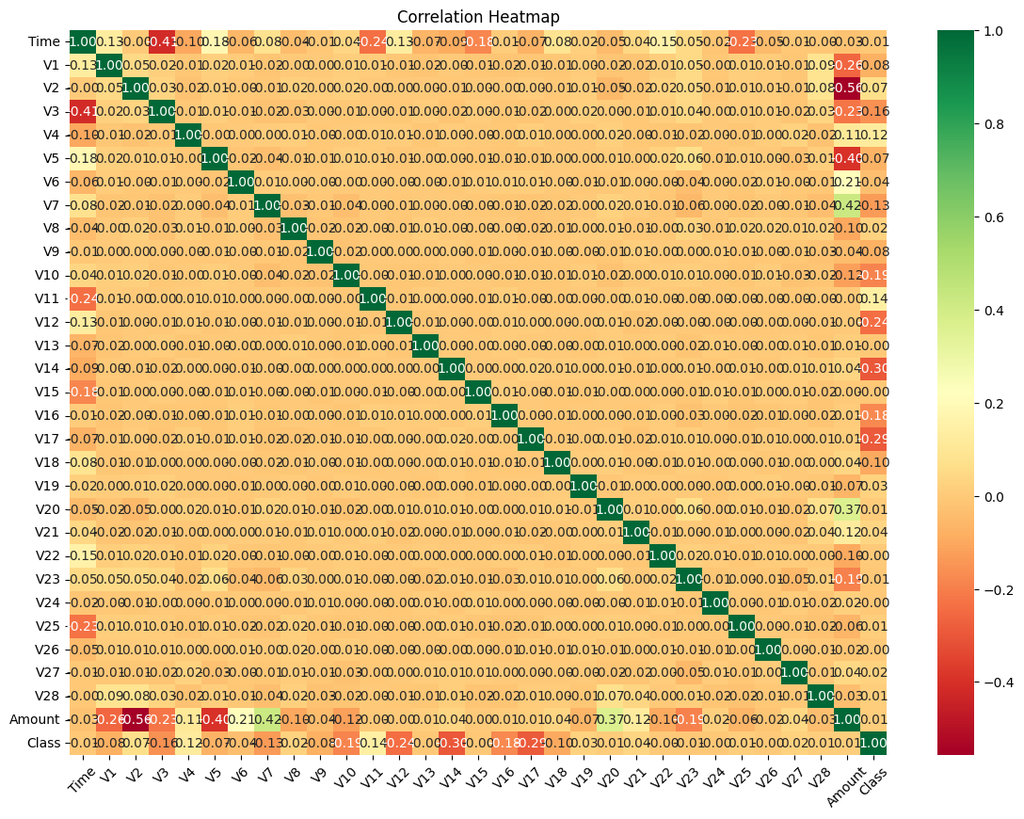

```python
# Get correlations of each feature in the dataset
corrmat = data1.corr()

# Get the index of the top correlated features
top_corr_features = corrmat.index

# Create a figure with a specific size
plt.figure(figsize=(14, 10))

# Plot a heatmap of the correlation matrix for data1
# 'annot=True' displays the correlation values in each cell
# 'cmap="RdYlGn"' sets the color map for the heatmap
# 'fmt='.2f'' formats the annotation to two decimal places
g = sns.heatmap(data1[top_corr_features].corr(), annot=True, cmap="RdYlGn", fmt='.2f')

# Adjust font size for better readability
plt.xticks(fontsize=10, rotation=45)
plt.yticks(fontsize=10)

# Add title to the plot
plt.title("Correlation Heatmap")

# Display the heatmap
plt.show()
```

```python
#Create independent and Dependent Features
columns = data1.columns.tolist()
# Filter the columns to remove data we do not want
columns = [c for c in columns if c not in ["Class"]]
# Store the variable we are predicting
target = "Class"
# Define a random state
state = np.random.RandomState(42)
X = data1[columns]
Y = data1[target]
X_outliers = state.uniform(low=0, high=1, size=(X.shape[0], X.shape[1]))
# Print the shapes of X & Y
print(X.shape)
print(Y.shape)
```

```
(28481, 30)
(28481,)
```

## Model Prediction

Now it is time to start building the model .The types of algorithms we are going to use to try to do anomaly detection on this dataset are as follows

### Isolation Forest Algorithm :

One of the newest techniques to detect anomalies is called Isolation Forests. The algorithm is based on the fact that anomalies are data points that are few and different. As a result of these properties, anomalies are susceptible to a mechanism called isolation.

This method is highly useful and is fundamentally different from all existing methods. It introduces the use of isolation as a more effective and efficient means to detect anomalies than the commonly used basic distance and density measures. Moreover, this method is an algorithm with a low linear time complexity and a small memory requirement. It builds a good performing model with a small number of trees using small sub-samples of fixed size, regardless of the size of a data set.

Typical machine learning methods tend to work better when the patterns they try to learn are balanced, meaning the same amount of good and bad behaviors are present in the dataset.

How Isolation Forests Work The Isolation Forest algorithm isolates observations by randomly selecting a feature and then randomly selecting a split value between the maximum and minimum values of the selected feature. The logic argument goes: isolating anomaly observations is easier because only a few conditions are needed to separate those cases from the normal observations. On the other hand, isolating normal observations require more conditions. Therefore, an anomaly score can be calculated as the number of conditions required to separate a given observation.

The way that the algorithm constructs the separation is by first creating isolation trees, or random decision trees. Then, the score is calculated as the path length to isolate the observation.

### Local Outlier Factor(LOF) Algorithm

The LOF algorithm is an unsupervised outlier detection method which computes the local density deviation of a given data point with respect to its neighbors. It considers as outlier samples that have a substantially lower density than their neighbors.

The number of neighbors considered, (parameter n_neighbors) is typically chosen 1) greater than the minimum number of objects a cluster has to contain, so that other objects can be local outliers relative to this cluster, and 2) smaller than the maximum number of close by objects that can potentially be local outliers. In practice, such informations are generally not available, and taking n_neighbors=20 appears to work well in general.

```python
# Define the outlier detection methods as a dictionary of classifiers
classifiers = {
    "Isolation Forest": IsolationForest(n_estimators=100, max_samples=len(X),
                                       contamination=outlier_fraction, random_state=state, verbose=0),
    "Local Outlier Factor": LocalOutlierFactor(n_neighbors=20, algorithm='auto',
                                              leaf_size=30, metric='minkowski',
                                              p=2, metric_params=None, contamination=outlier_fraction),
    "Support Vector Machine": OneClassSVM(kernel='rbf', degree=3, gamma=0.1, nu=0.05,
                                         max_iter=-1)
}

# Print the type of the 'classifiers' variable
print(type(classifiers))
```

```
<class 'dict'>
```

```python
# Get the number of fraudulent transactions
n_outliers = len(Fraud)

# Iterate over each classifier in the 'classifiers' dictionary
for i, (clf_name, clf) in enumerate(classifiers.items()):
    # Fit the data and tag outliers based on the classifier
    if clf_name == "Local Outlier Factor":
        # For Local Outlier Factor, predict outlier scores and tag outliers
        y_pred = clf.fit_predict(X)
        scores_prediction = clf.negative_outlier_factor_
    elif clf_name == "Support Vector Machine":
        # For Support Vector Machine, fit the model and predict outliers
        clf.fit(X)
        y_pred = clf.predict(X)
    else:
        # For other classifiers, fit the model, predict decision scores, and tag outliers
        clf.fit(X)
        scores_prediction = clf.decision_function(X)
        y_pred = clf.predict(X)

    # Reshape the prediction values to 0 for valid transactions and 1 for fraud transactions
    y_pred[y_pred == 1] = 0
    y_pred[y_pred == -1] = 1

    # Calculate the number of misclassified transactions
    n_errors = (y_pred != Y).sum()

    # Print the classifier name and the number of misclassified transactions
    print("{}: {}".format(clf_name, n_errors))

    # Print the accuracy score
    print("Accuracy Score:")
    print(accuracy_score(Y, y_pred))

    # Print the classification report
    print("Classification Report:")
    print(classification_report(Y, y_pred))
```

```
Isolation Forest: 73
Accuracy Score:
0.9974368877497279
Classification Report:
              precision    recall  f1-score   support

           0       1.00      1.00      1.00     28432
           1       0.26      0.27      0.26        49

    accuracy                           1.00     28481
   macro avg       0.63      0.63      0.63     28481
weighted avg       1.00      1.00      1.00     28481

Local Outlier Factor: 97
Accuracy Score:
0.9965942207085425
Classification Report:
              precision    recall  f1-score   support

           0       1.00      1.00      1.00     28432
           1       0.02      0.02      0.02        49

    accuracy                           1.00     28481
   macro avg       0.51      0.51      0.51     28481
weighted avg       1.00      1.00      1.00     28481

Support Vector Machine: 8516
Accuracy Score:
0.7009936448860644
Classification Report:
              precision    recall  f1-score   support

           0       1.00      0.70      0.82     28432
           1       0.00      0.37      0.00        49

    accuracy                           0.70     28481
   macro avg       0.50      0.53      0.41     28481
weighted avg       1.00      0.70      0.82     28481
```